# Ex09 Model Selection

Samuel Hudec

4 novembra 2018

Data s ktorými sme sa stretli v predchádzajúcich cvičeniach nám priamo určovali a ešte aj budú určovať **vesmír**. Vo väčšine prípadov dokonca obsahovali len nutné a relevantné regresory. **Realny svet** nám túto výhodu neposkytuje, zväčša si regresory musíme zvoliť v rámci možností sami.

- **Málo regresorov** (tolko aby sme ich vedeli obzrieť okom) nám dáva veľkú výhodu pri voľbe modelu. Po prvé môžeme podľa oka rozhotnuť použití jednotlivých regresorov a po druhé každý regresor preskúmame aj z hľadiska významu (predikovať cenu ropy na základe veľkosti topánok priemerneho muža je kus “nevhodné”).
- **Veľa regresorov** zatienuje predošlé možnosti, ťažko si ich znázrnime, vieme o každom z nich len čosi ak vôbec niečo (zväčša len názov).

V oboch prípadoch sa môžeme dostať do situácie kde si musíme vybrať model. Na to bolo navrhnutých niekoľko metód, mier, ale aj trikov aby ste sa vedeli rozhodnúť. V nasledujúcom cvičení nebudeme uvažovať transformácie ani diagnostiku modelu, ukážeme si len umelo výhody a nevýchody jednotlivých metód.

## Výber modelu vs. p-hodnota

```
##               Estimate Std. Error t value Pr(>|t|)
## (Intercept) 436.432128 166.571619  2.6201  0.01384
## Age           0.775716   0.570329  1.3601  0.18427
## Weight        0.026313   0.330970  0.0795  0.93718
## HtShoes      -2.692408   9.753035 -0.2761  0.78446
## Ht            0.601345  10.129874  0.0594  0.95307
## Seated        0.533752   3.761894  0.1419  0.88815
## Arm          -1.328069   3.900197 -0.3405  0.73592
## Thigh        -1.143119   2.660024 -0.4297  0.67056
## Leg          -6.439046   4.713860 -1.3660  0.18245
##
## n = 38, p = 9, Residual SE = 37.72029, R-Squared = 0.69
```

```
##              Estimate Std. Error t value Pr(>|t|)
## (Intercept) 436.84207  163.64104  2.6695  0.01214
## Age           0.76574    0.53590  1.4289  0.16337
## Weight        0.02897    0.32244  0.0898  0.92901
## HtShoes      -2.13409    2.53896 -0.8405  0.40726
## Seated        0.54959    3.68958  0.1490  0.88258
## Arm          -1.30087    3.80833 -0.3416  0.73504
## Thigh        -1.09039    2.46534 -0.4423  0.66145
## Leg          -6.40612    4.60272 -1.3918  0.17421
##
## n = 38, p = 8, Residual SE = 37.08854, R-Squared = 0.69
```

```
##              Estimate Std. Error t value Pr(>|t|)
## (Intercept) 427.50734  124.38767  3.4369 0.001696
## Age           0.77573    0.51579  1.5040 0.142709
## HtShoes      -2.08235    2.43289 -0.8559 0.398613
## Seated        0.58582    3.60833  0.1624 0.872083
## Arm          -1.28258    3.74154 -0.3428 0.734067
## Thigh        -1.11535    2.41013 -0.4628 0.646758
## Leg          -6.35716    4.49663 -1.4138 0.167396
##
## n = 38, p = 7, Residual SE = 36.49034, R-Squared = 0.69
```

```
##              Estimate Std. Error t value  Pr(>|t|)
## (Intercept) 436.54632  109.52662  3.9858 0.0003645
## Age           0.76671    0.50493  1.5185 0.1387169
## HtShoes      -1.77157    1.47856 -1.1982 0.2396483
## Arm          -1.33899    3.66826 -0.3650 0.7174980
## Thigh        -1.19826    2.31930 -0.5166 0.6089553
## Leg          -6.49097    4.35267 -1.4913 0.1456860
##
## n = 38, p = 6, Residual SE = 35.93092, R-Squared = 0.69
```

```
##              Estimate Std. Error t value  Pr(>|t|)
## (Intercept) 445.79773  105.14516  4.2398 0.0001695
## Age           0.65246    0.39097  1.6688 0.1046161
## HtShoes      -1.91711    1.40497 -1.3645 0.1816360
## Thigh        -1.37321    2.23923 -0.6133 0.5439130
## Leg          -6.95019    4.11181 -1.6903 0.1003972
##
## n = 38, p = 5, Residual SE = 35.45591, R-Squared = 0.68
```

```
##              Estimate Std. Error t value  Pr(>|t|)
## (Intercept) 456.21365  102.80779  4.4375 9.092e-05
## Age           0.59983    0.37792  1.5872   0.12173
## HtShoes      -2.30226    1.24520 -1.8489   0.07318
## Leg          -6.82975    4.06926 -1.6784   0.10244
##
## n = 38, p = 4, Residual SE = 35.12909, R-Squared = 0.68
```

```
##             Estimate Std. Error t value  Pr(>|t|)
## (Intercept) 493.7938   102.1923  4.8320 2.662e-05
## HtShoes      -2.4955     1.2658 -1.9714   0.05662
## Leg          -6.3693     4.1461 -1.5362   0.13347
##
## n = 38, p = 3, Residual SE = 35.88337, R-Squared = 0.66
```

```
##              Estimate Std. Error t value  Pr(>|t|)
## (Intercept) 565.59266   92.57945  6.1093 4.967e-07
## HtShoes      -4.26209    0.53906 -7.9065 2.207e-09
##
## n = 38, p = 2, Residual SE = 36.55490, R-Squared = 0.63
```

- Ste spokojný s modelom?
- Vedeli by ste **jednoznačne** obhájiť výber modelu?
- Dostali by ste rovnaký model keby ste použili **forward elimination**?

Vybraný citát z Faraway (2015): “We include it here because the method is still used but should be discouraged.”

## Výber modelu na základe informačného kritéria

Informačné kritériá sú jedni z najpoužívanejších pri voľbe modelu. Kritérium je miera vzdialenosti modelu od dát, to znamená, že neporovnávame sub modely, ale vzdialenosti. Spočítajte AIC pomocou rovnomennej funkcie plného modelu.

```
## [1] 393.4634
```

Číslo samé o sebe nám veľa nepovie jediné čo vieme je, že by malo byť čo najbližšie k 0. Nula je už zase nie dobre lebo to by znamenalo, že model sú dáta. Keby máme iný podľa nás “vhodnejší” model môžeme porovnať.

Pred tým než začneme je vhodné si urobiť pod množinu modelov, takých ktoré budú obsahovať vždy o jeden parameter menej. Na to môzeme použiť funkciu `regsubsets` z knižnice `leaps`. Funkcia používa niekoľko algoritmov na vytvorenie “najvhodnejších” modelov. *Je to len jedna z možnosí ako urobiť podmnožinu modelov.*

```r
summary(regsubsets(hipcenter~.,data=seatpos))
```

```
## Subset selection object
## Call: regsubsets.formula(hipcenter ~ ., data = seatpos)
## 8 Variables  (and intercept)
##         Forced in Forced out
## Age         FALSE      FALSE
## Weight      FALSE      FALSE
## HtShoes     FALSE      FALSE
## Ht          FALSE      FALSE
## Seated      FALSE      FALSE
## Arm         FALSE      FALSE
## Thigh       FALSE      FALSE
## Leg         FALSE      FALSE
## 1 subsets of each size up to 8
## Selection Algorithm: exhaustive
##          Age Weight HtShoes Ht  Seated Arm Thigh Leg
## 1  ( 1 ) " " " "    " "     "*" " "    " " " "   " "
## 2  ( 1 ) " " " "    " "     "*" " "    " " " "   "*"
## 3  ( 1 ) "*" " "    " "     "*" " "    " " " "   "*"
## 4  ( 1 ) "*" " "    "*"     " " " "    " " "*"   "*"
## 5  ( 1 ) "*" " "    "*"     " " " "    "*" "*"   "*"
## 6  ( 1 ) "*" " "    "*"     " " "*"    "*" "*"   "*"
## 7  ( 1 ) "*" "*"    "*"     " " "*"    "*" "*"   "*"
## 8  ( 1 ) "*" "*"    "*"     "*" "*"    "*" "*"   "*"
```

- Ako skúsený, vedeli by ste interpretovať výstup?
- Podľa submodelov aké algoritmus zvolil, vedeli by ste zvoliť model?

Vráťme sa k téme, AIC vieme spočítať aj sami podľa vzorca
$$nlog(RSS/n)+2p$$
spočítajte AIC submodelov z funkcie. (hint. RSS viete dostať zo summary funkcie zavolaním `$rss`)

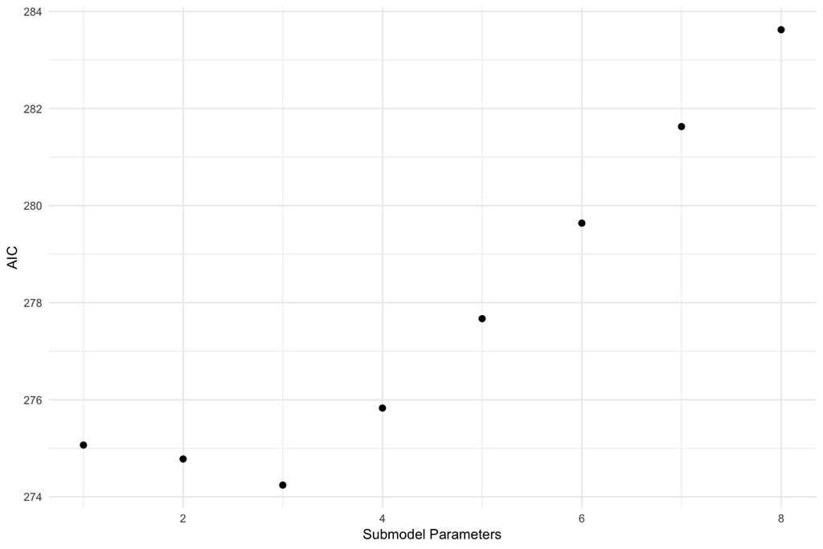

- Pokuste sa interpretovať obárzok.
- Aký model by ste podľa AIC zvolili?

Teraz vezmime funkciu `step` ktorá tiež používa AIC na voľbu vhodného modelu a použite ju na náš plný model.

```
##
## Call:
## lm(formula = hipcenter ~ Age + HtShoes + Leg, data = seatpos)
##
## Residuals:
##     Min      1Q  Median      3Q     Max
## -79.269 -22.770  -4.342  21.853  60.907
##
## Coefficients:
##             Estimate Std. Error t value Pr(>|t|)
## (Intercept) 456.2137   102.8078   4.438 9.09e-05 ***
## Age           0.5998     0.3779   1.587   0.1217
## HtShoes      -2.3023     1.2452  -1.849   0.0732 .
## Leg          -6.8297     4.0693  -1.678   0.1024
## ---
## Signif. codes:  0 '***' 0.001 '**' 0.01 '*' 0.05 '.' 0.1 ' ' 1
##
## Residual standard error: 35.13 on 34 degrees of freedom
## Multiple R-squared:  0.6813, Adjusted R-squared:  0.6531
## F-statistic: 24.22 on 3 and 34 DF,  p-value: 1.437e-08
```

- Dostali ste rovnaký model ako pomocou submodelov?
- Porovnajte ich hodnoty AIC.
- Aký predpoklad má metóda AIC (inými slovami je to aj slabina)

## Adjustované R^2

Máme podmožinu submodelov, čo je veľká výhoda a porovnajme ich $R^2$. Vo výstupe funkcie `regsubsets` nájdeme pod `$adjr2` tiež zo summary.

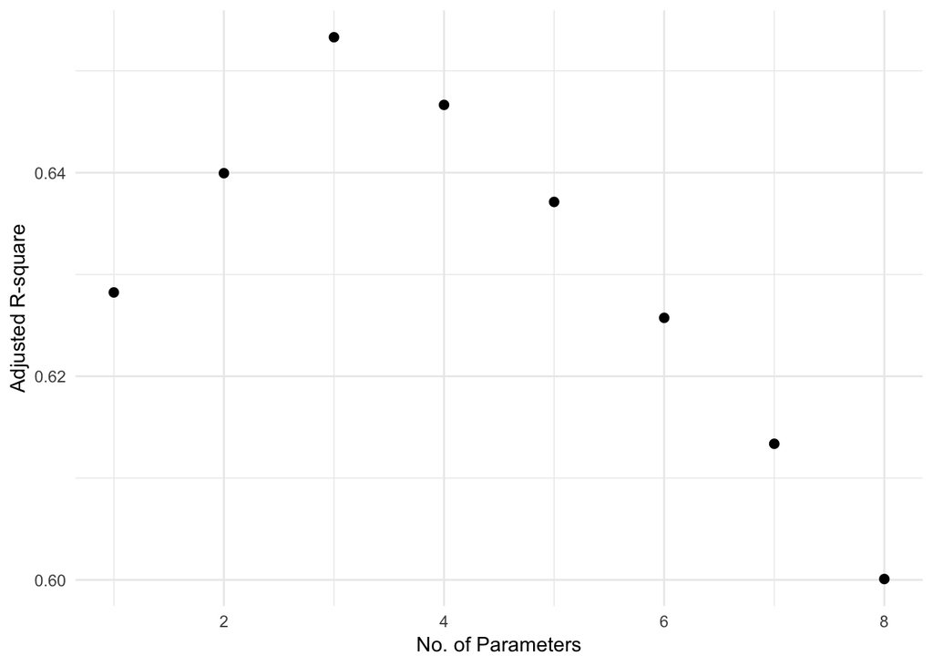

- Aký model by ste zvolili?

## Mallow Cp

Podobným nástrojom je aj miera Mallow Cp
$$C_p=\frac{RSS_p}{\sigma^2} + 2p -n.$$
Tu prichádza, znova vhod použitie funkcie `regsubsets`, ktorá tiež počíta aj tieto hodnoty a zavolať ich môžete pomocou `$cp` na summary.

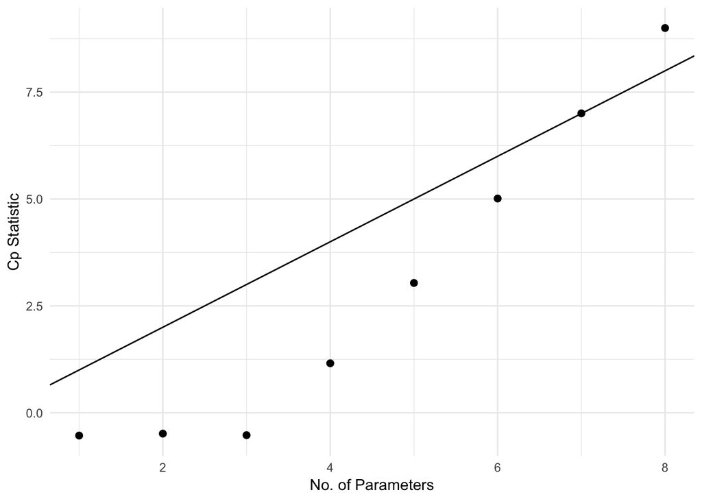

- Čomu sa má miera rovnať aby zvolila optimálny model?
- Spočítajte Mallow Cp pre model ktorý vybrala funkcia `step`.

## Teraz sa pozrime na dáta

Treba si uvedomiť, že použitie akéjkoľvek funkcie na vytvorenie submodelov má svoje hranice a možnosti. **Preto ich rady treba brať informačne.** Využite vaše skúsenosti nadobudnuté z predchádzajúcich kurzov a pokúste sa zložiť model podľa toho.

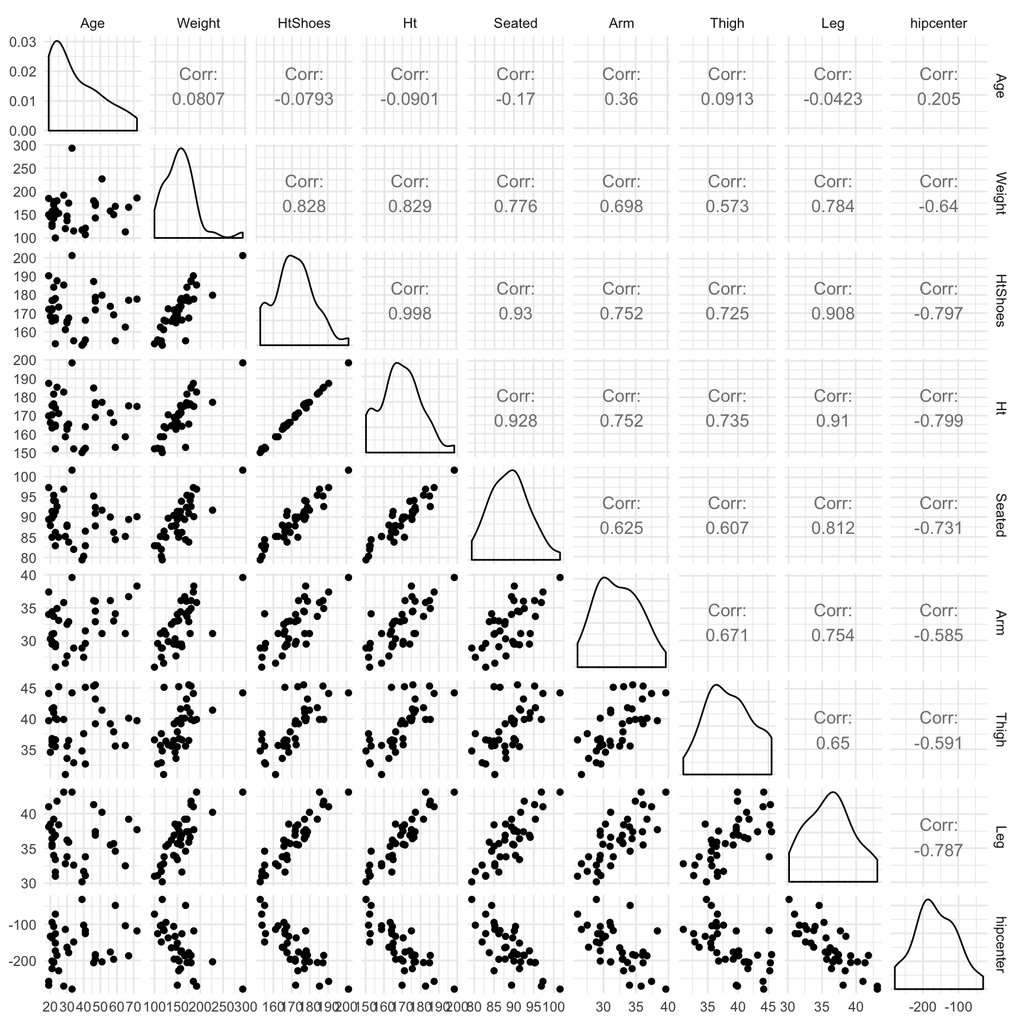

- Aký model by ste navrhli?
- Porovnajte tento model s najlepšími zo všetkých metód, ktoré sme prešli.

## Samostatná práca

Vezmite dáta `stackloss` a fitnite do dát podľa vás optimálny model s `temp` ako odozvou, pričom využite:

1. Backward elimination.
2. Informačné kriteria AIC a BIC.
3. $R^2$
4. Mallow Cp.
5. Vlastné oči.